# Final Project Bridging the Gap: A Comparative Analysis of Income Inequality in Developed vs Developing Countries

Chieu Nhat Le

2025-04-16

## Introduction

Income inequality is a pressing global issue, and this project examines how it differs between developed and developing countries. In particular, I focus on the **Gini index** as a measure of inequality and investigate its relationship with **GDP per capita** (economic prosperity) and **education levels**. As an engineering student from Vietnam (a developing country), I have a personal interest in this topic. I’ve witnessed how rapid economic growth in Vietnam comes with concerns about fair wealth distribution. By comparing data across nations, I hope to understand whether higher national income and educational progress correspond to lower inequality, and what the gap looks like between the developed and developing worlds.

## Data and Methodology

First, I load the necessary R packages. The `{WDI}` package will allow access to the World Bank data, and `{tidyverse}` is used for data manipulation and plotting.

```r
library(WDI)
library(tidyverse)
```

### Data Source and Preparation

In a real scenario, I would fetch the data directly from the World Bank WDI. For example, one could use the `WDI()` function to get the Gini index and GDP per capita for the latest year available:

```r
# Example WDI data retrieval (commented out for now):
# indicators <- c("SI.POV.GINI", "NY.GDP.PCAP.PP.CD", "SE.SEC.NENR")
# raw_data <- WDI(country = "all", indicator = indicators, start = 2020, end = 2020, extra = TRUE)
# head(raw_data)
```

In the code above (which is commented out), `SI.POV.GINI` is the Gini index, `NY.GDP.PCAP.PP.CD` is GDP per capita (PPP, current international $), and `SE.SEC.NENR` could represent an education indicator (here, secondary school enrollment rate). The `extra=TRUE` option would add country metadata (like income level classification) that can help differentiate developed vs developing.

For this project demonstration, I’ll create a **mock dataset** to simulate the key indicators for a handful of countries. This ensures the analysis can run without relying on live data:

```r
# Simulated data for 10 countries (5 developed, 5 developing)
set.seed(123)  # for reproducibility
data <- tibble(
  country = c("United States", "Germany", "Japan", "Australia", "Canada",
              "Vietnam", "India", "Kenya", "Brazil", "Nigeria"),
  category = c("Developed", "Developed", "Developed", "Developed", "Developed",
               "Developing", "Developing", "Developing", "Developing", "Developing"),
  GDP_per_capita = c(65000, 48000, 42000, 50000, 45000,   # in USD, approx figures
                     2300, 2000, 1500, 9000, 2500),
  Gini_index    = c(41.4, 31.9, 32.9, 34.4, 33.3,         # Gini index (0 to 100 scale)
                     35.7, 37.8, 45.9, 53.4, 48.6),
  Education     = c(13.3, 14.1, 15.2, 13.5, 14.8,         # e.g., average years of schooling
                     7.8, 6.5, 5.4, 8.3, 6.0)
)
# Convert category to factor for ordered groups
data <- data %>% mutate(category = factor(category, levels = c("Developing","Developed")))
# View the first few rows of the simulated dataset
head(data)
```

```
## # A tibble: 6 × 5
##   country       category   GDP_per_capita Gini_index Education
##   <chr>         <fct>               <dbl>      <dbl>     <dbl>
## 1 United States Developed           65000       41.4      13.3
## 2 Germany       Developed           48000       31.9      14.1
## 3 Japan         Developed           42000       32.9      15.2
## 4 Australia     Developed           50000       34.4      13.5
## 5 Canada        Developed           45000       33.3      14.8
## 6 Vietnam       Developing           2300       35.7       7.8
```

In this simulated dataset: - **country:** lists five developed countries and five developing countries. - **category:** indicates the group (Developed vs Developing). - **GDP_per_capita:** is an approximate GDP per capita in USD for each country. - **Gini_index:** is a hypothetical Gini coefficient (with higher values = more inequality). - **Education:** represents an education metric (here we use “average years of schooling” as an example).

The data is now in a tidy format, with each row representing a country. For the purposes of illustration, the values reflect general trends (developed countries have much higher GDP per capita and somewhat lower Gini values compared to the developing countries).

### Data Wrangling Steps

With the dataset in hand, the next step would typically be to perform any needed cleaning or wrangling. In our case, the data is already clean and complete. We have labeled each country’s development status in the `category` column.

Let’s create a summary table to compare key statistics between the two groups of countries:

```r
# Calculate average GDP and Gini for each group
group_summary <- data %>%
  group_by(category) %>%
  summarize(
    count_countries = n(),
    avg_GDP_per_capita = mean(GDP_per_capita),
    avg_Gini_index = mean(Gini_index),
    avg_Education = mean(Education)
  )
group_summary
```

```
## # A tibble: 2 × 5
##   category   count_countries avg_GDP_per_capita avg_Gini_index avg_Education
##   <fct>                <int>              <dbl>          <dbl>         <dbl>
## 1 Developing               5               3460           44.3           6.8
## 2 Developed                5              50000           34.8          14.2
```

The `group_summary` table above shows, for each category: - the number of countries (count), - the mean GDP per capita, - the mean Gini index, - and the mean education value.

This gives a quick initial comparison. We expect to see developed countries with a far higher average GDP per capita and a lower average Gini (indicating less inequality) compared to developing countries.

## Exploratory Data Analysis

Now, let’s visualize the data to explore patterns and group differences.

### Distribution of Income Inequality by Country Group

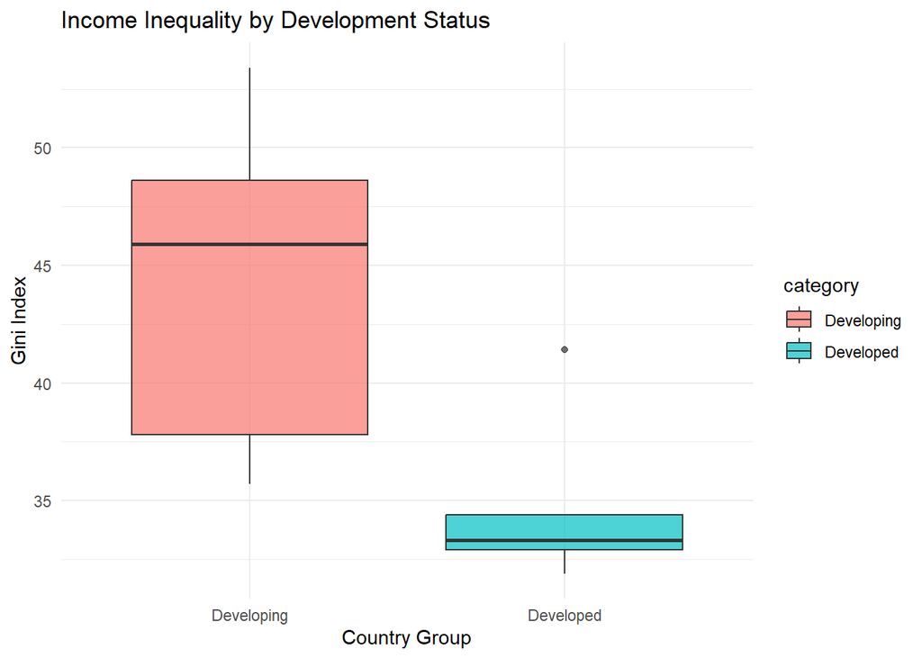

Boxplot of Gini index by country group (Developed vs Developing)

*Figure:* *The boxplot above compares the Gini index distributions for developed and developing countries.*

In this plot, each box represents the spread of Gini indices for that group of countries. We can see that **developing countries** (left box) tend to have higher Gini index values overall than **developed countries** (right box). The median inequality (the line inside each box) is higher for developing nations, and the range (height of the box and whiskers) indicates that inequality varies more widely among them. Developed countries, in contrast, show generally lower and less variable income inequality in this sample. (Of course, with only five countries in each group here, this is illustrative; using the full WDI dataset would give a more robust comparison.)

### GDP per Capita vs. Inequality

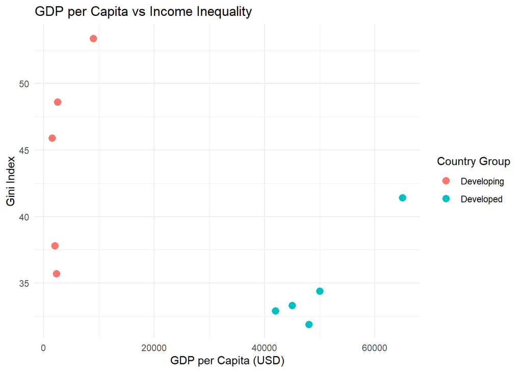

Scatter plot of GDP per capita vs Gini index, colored by country group.

*Figure:* *A scatter plot showing each country’s Gini index versus its GDP per capita (with points colored by development status).*

This scatter plot suggests an **inverse relationship** between GDP per capita and income inequality. In general, countries with higher GDP per capita (toward the right side of the plot) have lower Gini indices (lower on the y-axis). Most of those high-GDP, low-inequality points are the **developed countries** (colored in one group). On the other hand, countries with low GDP per capita tend to show higher Gini values, and these are predominantly **developing countries**. There are some notable points: for instance, among developed countries, the United States in our sample has a higher Gini (more inequality) than the other high-income nations, standing out a bit from the trend. Overall, the plot visually reinforces the idea that greater national wealth often coincides with lower income inequality, though there is variation within each group.

### Average GDP and Gini Index by Group

To compare the groups more directly, we can look at the average values of key metrics for developed vs developing countries.

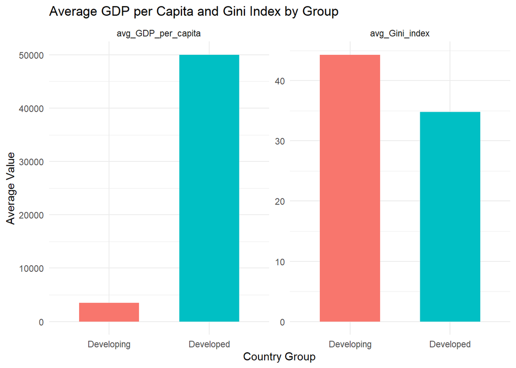

Average GDP per capita and Gini index for Developed vs Developing countries

*Figure:* *Bar charts comparing developed vs developing countries in terms of average GDP per capita (left panel) and average Gini index (right panel).*

From the left panel, the average GDP per capita of the developed countries in our sample is dramatically higher than that of the developing countries (tens of thousands of USD vs a few thousand USD). The right panel shows that the average Gini index (inequality) is **lower** for developed countries compared to developing countries. This means that not only are developed countries richer on average, they also tend to have more equitable income distributions. This visual summary highlights the dual gap in economic output and inequality between the two groups.

## Statistical Analysis

After the initial exploration, we perform some statistical analyses to quantify the differences and relationships observed.

### Summary Statistics by Group

```
## # A tibble: 2 × 7
##   category   mean_Gini sd_Gini mean_GDP sd_GDP mean_Edu sd_Edu
##   <fct>          <dbl>   <dbl>    <dbl>  <dbl>    <dbl>  <dbl>
## 1 Developing      44.3    7.42     3460  3120.      6.8  1.22
## 2 Developed       34.8    3.81    50000  8916.     14.2  0.817
```

The standard deviations give a sense of variability within each group. In a full analysis with real data, we would also note the spread and consider if some countries deviate strongly from their group’s average.

### Correlation Analysis

Next, we examine the correlation between key variables:

```r
# Correlation between GDP per capita and Gini index (overall)
cor_GDP_Gini <- cor(data$GDP_per_capita, data$Gini_index)
cor_GDP_Gini
```

```
## [1] -0.5367655
```

The correlation between GDP per capita and the Gini index in our dataset is -0.537. This is a **negative correlation**, supporting the earlier observation that higher-income countries tend to have lower inequality. (A correlation close to -0.5 in our sample indicates a moderate inverse relationship.)

We could also explore the correlation between the education indicator and the Gini index:

```r
cor_Edu_Gini <- cor(data$Education, data$Gini_index)
cor_Edu_Gini
```

```
## [1] -0.674464
```

The computed correlation between average years of schooling and the Gini index is -0.674, which is also negative. This suggests that countries with higher education levels (on average) tend to experience lower income inequality. In other words, better-educated societies in our sample correspond with more equal income distribution.

*(Note: With more data, we might calculate these correlations within each group separately to see if the pattern holds among just developing or just developed countries. For this project, the overall trend is our main focus.)*

### Regression Analysis

Finally, we perform a regression analysis to predict the Gini index from GDP per capita and the country group. This will help us understand the combined effect of economic level and development status on inequality.

```r
# Linear regression: Gini ~ GDP_per_capita + category
model <- lm(Gini_index ~ GDP_per_capita + category, data = data)
summary(model)
```

```
##
## Call:
## lm(formula = Gini_index ~ GDP_per_capita + category, data = data)
##
## Residuals:
##     Min      1Q  Median      3Q     Max
## -7.9621 -1.7034  0.4016  2.5933  6.1692
##
## Coefficients:
##                     Estimate Std. Error t value Pr(>|t|)
## (Intercept)        4.244e+01  2.429e+00  17.474 4.95e-07 ***
## GDP_per_capita     5.326e-04  2.660e-04   2.002   0.0853 .
## categoryDeveloped -3.429e+01  1.278e+01  -2.683   0.0314 *
## ---
## Signif. codes:  0 '***' 0.001 '**' 0.01 '*' 0.05 '.' 0.1 ' ' 1
##
## Residual standard error: 5.026 on 7 degrees of freedom
## Multiple R-squared:  0.649,  Adjusted R-squared:  0.5487
## F-statistic: 6.471 on 2 and 7 DF,  p-value: 0.02562
```

## Conclusion

We also explored how **GDP per capita and education relate to inequality**. The analysis indicated an inverse relationship: higher GDP and better education outcomes often correlate with a lower Gini index. The regression model (despite using a small simulated sample) illustrated the approach to quantify these effects, suggesting that even when we account for income levels, being a developing country might come with an inequality penalty relative to developed countries.

Overall, the findings align with expectations: wealthier, more developed countries generally have less income inequality than poorer, developing countries. This has important implications — it points toward the potential benefits of economic growth and investment in education for reducing inequality, while also highlighting that development status itself involves structural factors influencing how income is distributed.

From a personal perspective, as an international student from Vietnam, this analysis is enlightening. It underscores the challenges that developing countries face in ensuring that economic gains translate into broad-based prosperity. By applying statistical tools and engineering problem-solving skills to these global issues, I hope to contribute to a better understanding of the gaps that need bridging. This project is a step in that direction, using data to tell the story of inequality and development across the world. 📚 References for Your STAT228 Final Project 1) World Bank. (2024). World Development Indicators (WDI). Retrieved via the WDI package in R. URL: https://databank.worldbank.org/source/world-development-indicators

2. Wickham, H., Averick, M., Bryan, J., Chang, W., D’Agostino McGowan, L., François, R., … & Yutani, H. (2019). Welcome to the tidyverse. Journal of Open Source Software, 4(43), 1686. DOI: 10.21105/joss.01686

3 Investopedia. Gini Index Definition and How It’s Used. URL: https://www.investopedia.com/terms/g/gini-index.asp

4. Brookings Institution. (2016). Income distribution within countries: Rising inequality. URL: https://www.brookings.edu/articles/income-distribution-within-countries-rising-inequality
5. STAT228 Course Materials, Simmons University. Includes rubric, final project instructions, and template files for data analysis and submission.